# Exploratory Analysis

## Project title

How Income Levels are Affected by Race, Gender, and Education

### Authors

Brianna, Aldrich, Audrey and Rahma

### Date

May 17, 2024

### Abstract

Our main question is: to what extent do disparities between racial groups in education and occupation affect income? This question is important because we want to understand how the intersection of certain factors affect economic inequality in the United States. We plan to analyze data sets in order to recognize patterns and trends in how identity factors such as race and gender influence eventual economic outcomes.

### Keywords

Income, race, gender, education

### Introduction

Our project primarily investigates the data trends of income grouped by race. We will also be analyzing other considered factors such as gender, age, occupation, and education level. Our aim is to understand how these factors affect economic outcomes in households in the United States. Some research questions that motivate our research topic are: to what extent do disparities between racial groups in education and occupation affect household income? What are the primary factors that seem to influence household income? How does the intersection of race, gender, and education level affect household income? We want to understand which of these factors may weigh more in terms of salary outcomes, and how these factors may help or hurt certain groups of people. This is an important concept to analyze in order to understand how certain privileged groups are able to stay privileged, and how difficult it can be for marginalized groups to break the cycle of poverty. Additionally, this is an important research topic as we can address systemic inequalities and find ways to develop attainable solutions. This can provide both systemic and historical contexts into how racialized institutions are still affecting our society today. We will be able to better understand how intersectionality and overlapping factors influence economic outcomes.

### Related Work

While our topic primarily focuses on income inequality as a result of racial disparities, there are many contributing factors to this inequality. Intersectionality is the idea that multiple forms of inequality or disadvantages sometimes compound themselves and create obstacles that often are not understood among conventional ways of thinking. Understanding that racial disparities are not the lone contributing factor to income inequality broadens the debate to consider other factors such as gender, education, sexuality, and other defining characteristics of unique individuals that can contribute to income inequality. The following three articles reaffirm the role race plays regarding income, as well as highlighting other contributing factors and providing possible solutions to combat it. The first article by the U.S. Department of Treasury highlights racial inequality in the United States. They define racial inequality as the unequal distribution of resources, power and economic opportunity across race in a society. The article includes various statistics and graphs that depict the prevalence of the issue. For example, a graph showed that the median household income in 2020 was roughly $46,000 and $55,000 for Black and Hispanic workers, respectively, compared to $75,000 and $95,000 for white and Asian households. “Racial Inequality in the United States.” U.S. Department of the Treasury, 21 July 2022, home.treasury.gov/news/featured-stories/racial-inequality-in-the-united-states#:~:text=In%20addition%2C%20Black%20and%20Hispanic,as%20shown%20in%20Figure%204. The next article by the Pew Research Center reaffirms the inequality in income between races, but it adds another layer of complexity to the issue. Along with racial disparities, they also consider how other factors, such as gender, play a role in income inequality. They make this abundantly clear with the following statistics: In 2022, Black women earned 70% as much as White men and Hispanic women earned only 65% as much. The ratio for White women stood at 83% about the same as the earnings gap overall, while Asian women were closer to parity with White men, making 93% as much. Kochhar, Rakesh. “The Enduring Grip of the Gender Pay Gap.” Pew Research Center, Pew Research Center, 1 Mar. 2023, www.pewresearch.org/social-trends/2023/03/01/the-enduring-grip-of-the-gender-pay-gap/#:~:text=In%202022%2C%20Black%20women%20earned,%2C%20making%2093%25%20as%20much. Lastly, another article by the Pew Research Center analyzes where the power lies when it comes to fighting income inequality. According to their research, most Americans agree that the federal government and large corporations hold high responsibility in reducing inequality. They included a graph that ranks the responsibility/power for a certain group to reduce inequality. The results are as follows: The federal government at 66%, large business and corporations at 62%, state governments at 52%, wealthy individuals at 46%, and lastly churches/other religious organizations at 13%. This shows that the solution to income inequality lies among those with positions of high power. Juliana Menasce Horowitz, Ruth Igielnik and Rakesh Kochhar. “4. Views on Reducing Economic Inequality.” Pew Research Center, Pew Research Center, 9 Jan. 2020, www.pewresearch.org/social-trends/2020/01/09/views-on-reducing-economic-inequality/.

### The Dataset

**Where did you find the data? Please include a link to the data source**

https://www.kaggle.com/datasets/mastmustu/income https://archive.ics.uci.edu/dataset/2/adult

**Who collected the data?**

Mustafa Fatakdawala.

**How was the data collected or generated?**

Specific details about the methodology of data collection or generation are not provided on the dataset page. But usually data sets are collected from surveys, synthetic data generation or government records.

**Why was the data collected?**

**How many features (columns) are in the data?**

There are 15 features in the dataset.

**What, if any, ethical questions or questions of power do you need to consider when working with this data?**

Ensure that the data does not contain personally identifiable information. If it does, proper measures must be taken to anonymize the data to protect individuals’ privacy.

Analyze whether the dataset includes any biases towards certain groups based on race, gender, age, etc. This is crucial to avoid perpetuating or amplifying societal inequalities through your analysis.

Consider how the data was collected. It’s important to know whether the individuals whose data is included provided informed consent and if the data collection methods were ethical.

Reflect on how the results of your analysis might be used. Consider the potential social, economic, and political impacts, especially on vulnerable populations.

**What are possible limitations or problems with this data? (at least 200 words)**

The Income Dataset from Kaggle, despite its usefulness for economic and demographic analysis, presents several challenges that could undermine its effectiveness and ethical integrity. The dataset lacks comprehensive documentation detailing the methodology of data collection, which raises questions about the accuracy and representativeness of the data. This gap in information makes it difficult to assess the reliability of any findings derived from the data. Also, there’s concern about the completeness of the dataset. Missing values or incomplete records can skew analyses, leading to potentially biased outcomes that do not accurately reflect the population being studied. The dataset may harbor inherent biases if the data collection did not adequately control for a diverse and representative sample. Such biases can affect the generalizability of the results, potentially leading to conclusions that are not applicable to broader populations. Another significant issue is the timeliness of the data. If the data was collected in the past, it might not reflect current economic realities or demographic shifts, which can be crucial for studies intended to inform current policy or business decisions. Lastly, the use of personal income data involves several ethical and legal considerations, particularly concerning privacy and consent. If the data includes personally identifiable information or was collected without explicit consent, there could be serious ethical violations, alongside potential legal repercussions.

### Implications

It can be seen that from the data that we analyze, it’s true that based on the data. That in terms of education they don’t really have that much disparities between them. The data seems to be heavily relying on what type of company that you worked for, like do you work for a local government or private company? Because this will likely make the disparities between the incomes more larger. It also seems that race is also a part of it by seeing how Asian-Pac-Islander have the lowest income even though they have the same amount of education or lower and working in the same type of company. Even if they work for a private company, it would still be low compared to the other races. In term of gender, it seems pretty fair that the women incomes are in that state because in terms of education or the type of company they worked for it’s seem that there aren’t that big gap of disparities between them, but that is true for some races, but for specific races, the disparities would be high.

### Limitations & Challenges

The challenges or limitations that we might encounter is that not all people are open or willing to share their incomes to strangers. It might also be uncomfortable for them to tell us what company they worked for or what is your relationship? Are you single, Married, or divorced? Or we ask about their education that they might be embarrassed of because they don’t have a good academic background or didn’t go to school or a dropout. This type of information is necessary for our project and it’s this information that may be a little bit sensitive to talk about or people can be fully lying because they don’t want us to know. If so, then the data that we will collect would be useless because it’s not an accurate representation of people’s incomes and it will impact our result of what the data tells us. It’s also important for us to keep the information confidential because of how these types of information can impact someone’s life based on what is used for.

### Table

Table of aggregate information

```r
# Load necessary libraries
library(dplyr)

# Load the dataset
data <- read.csv("./income_data.csv")

aggregate_table <- data %>%
  group_by(education) %>%
  summarise(
    `Total Count` = n(),
    `Average Age` = round(mean(age, na.rm = TRUE), 1),
    `Black Count` = sum(race == "Black", na.rm = TRUE),
    `White Count` = sum(race == "White", na.rm = TRUE),
    `Male Count` = sum(gender == "Male", na.rm = TRUE),
    `Female Count` = sum(gender == "Female", na.rm = TRUE)
  ) %>%
  arrange(desc(`Total Count`))

# Print the aggregate table
print(aggregate_table)
```

```
## # A tibble: 16 × 7
##    education    `Total Count` `Average Age` `Black Count` `White Count`
##    <chr>                <int>         <dbl>         <int>         <int>
##  1 HS-grad                302          39.6            36           256
##  2 Some-college           198          36.2            21           170
##  3 Bachelors              142          37.5             8           126
##  4 Masters                 61          42.3             2            57
##  5 11th                    34          34              10            23
##  6 Assoc-acdm              33          36.5             2            30
##  7 Assoc-voc               33          38.8             2            28
##  8 10th                    26          37               3            23
##  9 Prof-school             15          43.1             0            15
## 10 7th-8th                 13          46.7             0            12
## 11 12th                    12          33               2            10
## 12 9th                     10          41.8             4             6
## 13 Doctorate               10          52.6             0             9
## 14 5th-6th                  5          48.6             0             5
## 15 1st-4th                  3          42.3             0             3
## 16 Preschool                2          40               0             2
## # ℹ 2 more variables: `Male Count` <int>, `Female Count` <int>
```

### Chart 1

Link to display chart: file://Users/andrewyu/Dekstop/info%20prjct/chart1.html

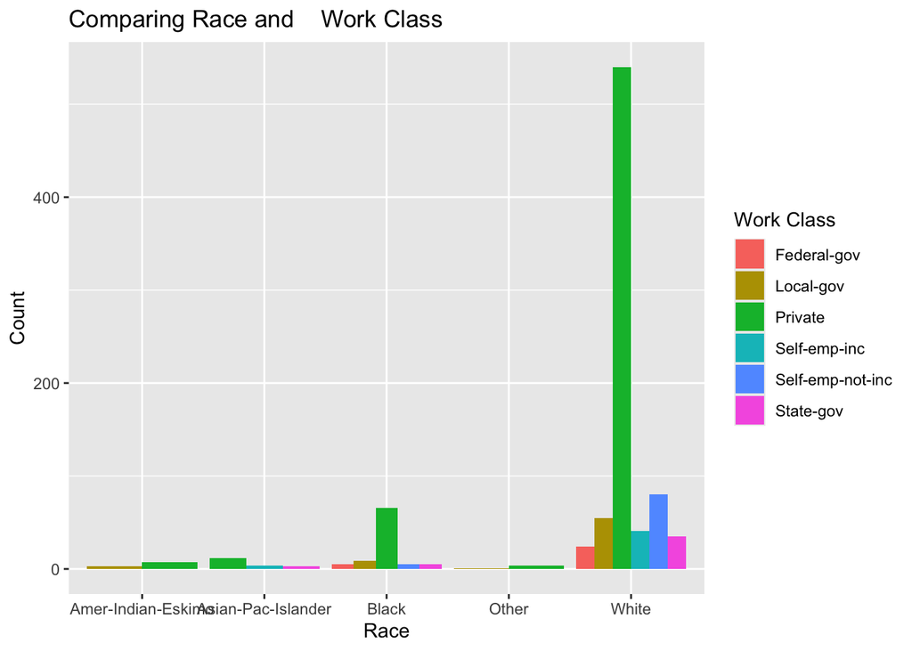

```r
library(tidyverse)
library(readr)

data <- read_csv("./income_data.csv")
ggplot(data, aes(x = race, fill = workclass)) +
  geom_bar(position = "dodge") +
  labs(x = "Race", y = "Count", fill = "Work Class", title = "Comparing Race and    Work Class")
```

This chart displays race compared to workclass. As shown, White individuals have the highest rate of employment in all of the included classes (federal gov, local gov, private, self-emp-inc, self-emp-not-inc, and state-gov). The most noticeable disparity is the difference between White people that are employed in private work classes compared to those of other races. White has the highest number, with a count over 500, whereas Black comes in second, with less than 100. This not only shows that race plays a role in employment, but that its impact seems to be significant. Level of employment directly translates to level of income, which is why analyzing how race plays a role in employment is important to tackling racial disparities regarding income.

### Chart 2

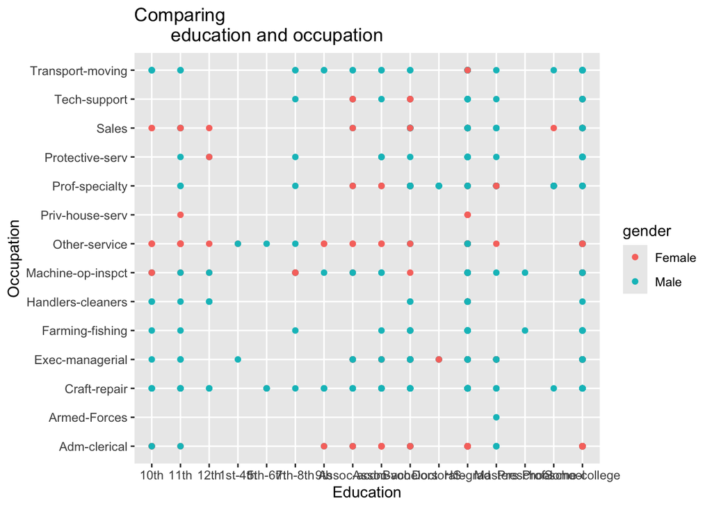

```r
ggplot(data, mapping = aes(x = education, y = occupation, color = gender)) +
  geom_point(position = "dodge") +
  labs(x = "Education", y = "Occupation", fill = "Gender", title = "Comparing
       education and occupation")
```

This chart displays education compared to occupation. As shown, higher education has the highest rate of employment compare to those who dropped out early in shchool or didn’t proceed higher education like college. Using this graph we don’t need to know what exactly the people hired in that specific occupation, but this graph is used for seeing the contrast between high education and low education. As it’s shown in the lower education, there only 2 jobs that are willing to employ them, whereas the higher education have much more job opportunities and the quality of the job is also much higher compare to the lower education.

### Chart 3

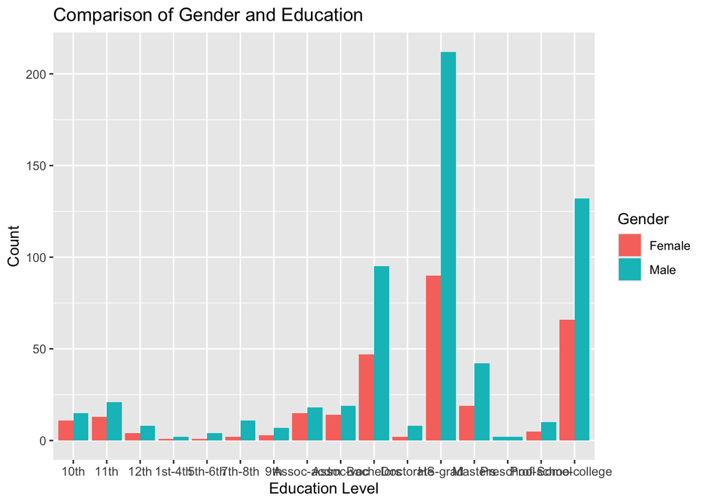

```r
summary_data <- data %>%
  group_by(gender, education) %>%
  summarise(Count = n()) %>%
  ungroup()

ggplot(summary_data, aes(x = education, y = Count, fill = gender)) +
  geom_bar(stat = "identity", position = "dodge") +
  labs(title = "Comparison of Gender and Education",
       x = "Education Level",
       y = "Count",
       fill = "Gender")
```

I chose this chart to display the gender differences in education level because it can help us understand how gender roles play a part in completion of education. We can see through the bar chart that most of the bars for males are higher than females in terms of education level. This could be attributed to the fact that more entries in the dataset were male instead of female, but it could also indicate that males completed higher levels of education in general.